# Practical Machine Learning

Klemen Rizman

January 25, 2017

# Synopsis

One thing that people regularly do is quantify how much of a particular activity they do, but they rarely quantify how well they do it. In this project, my goal will be to use data from accelerometers on the belt, forearm, arm, and dumbell of 6 participants.

# Preparations

## Download & read data

```r
train <- read.csv(url("https://d396qusza40orc.cloudfront.net/predmachlearn/pml-training.csv"),
                  na.strings = c("NA","","#DIV/0!"), header = TRUE)
test <- read.csv(url("https://d396qusza40orc.cloudfront.net/predmachlearn/pml-testing.csv"),
                  na.strings = c("NA","","#DIV/0!"), header = TRUE)
```

## Clean data

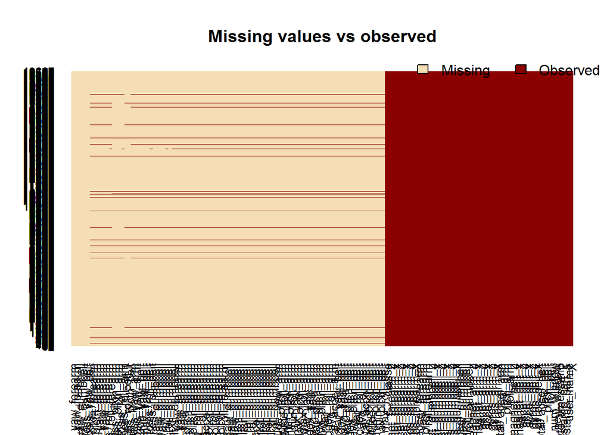

```r
missmap(train, main = "Missing values vs observed")
```

```r
naVal <- is.na(train)
train <- train[,colSums(naVal) == 0]
test <- test[,colSums(naVal) == 0]

zeroVar <- nearZeroVar(train)
train <- train[,-zeroVar]
test <- test[,-zeroVar]
train <- train[,-(1:6)]
test <- test[,-(1:6)]
test$problem_id <- NULL
```

## Test & train data set for learning

I have created train and test set from training data. Train set is 60% and test set is 40% of training data. This was made for resampling

```r
set.seed(42)
inTrain <- createDataPartition(train$classe, p = 0.6, list = FALSE)
trainSet <- train[inTrain,]
testSet <- train[-inTrain,]
```

# Predictions

With this models we will try to pridict variable classe, with all predictors there were left from cleaning process. Then I will look at accuracies and choose a model with highest accuracy. For resampling I was choosing between bootstrap, croos validation and LOOCV. I choose cross validation with 10 subsets, because I found out that I have eto choose it.

## Decision Tree

```r
fitControl <- trainControl(method = "cv", number = 10, allowParallel = TRUE)
fitDT <- train(classe ~ .,data = trainSet, method = "rpart", trControl = fitControl)
predictionDT = predict(fitDT,testSet)
confusionMatrix(testSet$classe,predictionDT)
```

```
## Confusion Matrix and Statistics
##
##           Reference
## Prediction    A    B    C    D    E
##          A 2024   41  161    0    6
##          B  625  515  378    0    0
##          C  644   39  685    0    0
##          D  573  245  468    0    0
##          E  230  188  370    0  654
##
## Overall Statistics
##
##                Accuracy : 0.4943
##                  95% CI : (0.4831, 0.5054)
##     No Information Rate : 0.522
##     P-Value [Acc > NIR] : 1
##
##                   Kappa : 0.3388
##  Mcnemar's Test P-Value : NA
##
## Statistics by Class:
##
##                      Class: A Class: B Class: C Class: D Class: E
## Sensitivity            0.4941  0.50097  0.33220       NA  0.99091
## Specificity            0.9445  0.85289  0.88192   0.8361  0.89034
## Pos Pred Value         0.9068  0.33926  0.50073       NA  0.45354
## Neg Pred Value         0.6309  0.91893  0.78743       NA  0.99906
## Prevalence             0.5220  0.13102  0.26281   0.0000  0.08412
## Detection Rate         0.2580  0.06564  0.08731   0.0000  0.08335
## Detection Prevalence   0.2845  0.19347  0.17436   0.1639  0.18379
## Balanced Accuracy      0.7193  0.67693  0.60706       NA  0.94063
```

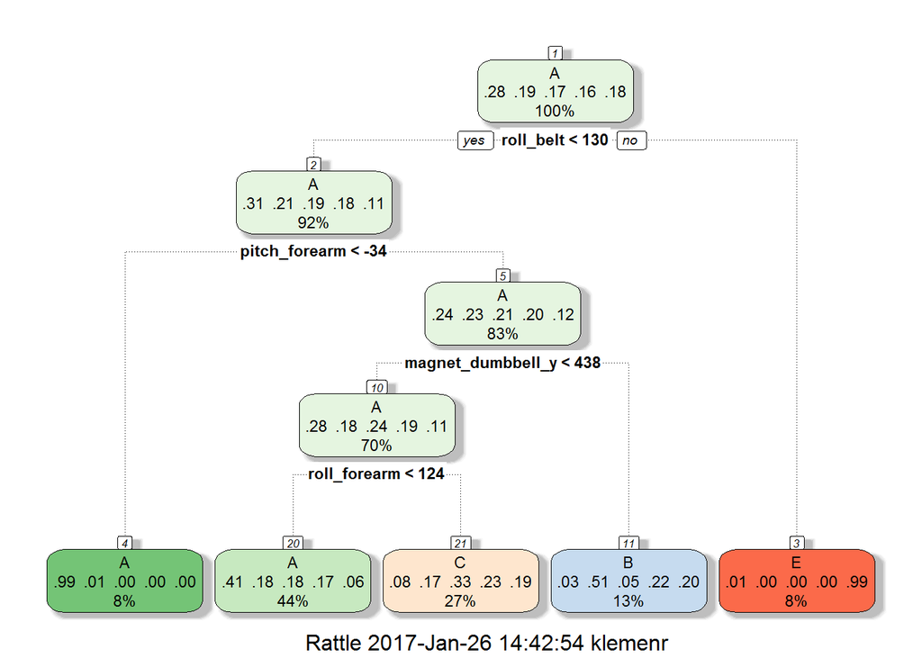

```r
fancyRpartPlot(fitDT$finalModel)
```

## Generalized Boosted Regression Model GBM

```r
cluster <- makeCluster(detectCores() - 1) # convention to leave 1 core for OS
registerDoParallel(cluster)
fitGBM <- train(classe ~ .,data = trainSet, method = "gbm", trControl = fitControl)
stopCluster(cluster)
registerDoSEQ()
predictionGBM = predict(fitGBM,testSet)
confusionMatrix(testSet$classe,predictionGBM)
```

```
## Confusion Matrix and Statistics
##
##           Reference
## Prediction    A    B    C    D    E
##          A 2188   24    7   13    0
##          B   45 1426   39    4    4
##          C    0   39 1317   12    0
##          D    1    9   41 1227    8
##          E    0   13    9   23 1397
##
## Overall Statistics
##
##                Accuracy : 0.9629
##                  95% CI : (0.9585, 0.967)
##     No Information Rate : 0.2847
##     P-Value [Acc > NIR] : < 2.2e-16
##
##                   Kappa : 0.9531
##  Mcnemar's Test P-Value : NA
##
## Statistics by Class:
##
##                      Class: A Class: B Class: C Class: D Class: E
## Sensitivity            0.9794   0.9437   0.9321   0.9593   0.9915
## Specificity            0.9922   0.9855   0.9921   0.9910   0.9930
## Pos Pred Value         0.9803   0.9394   0.9627   0.9541   0.9688
## Neg Pred Value         0.9918   0.9866   0.9852   0.9921   0.9981
## Prevalence             0.2847   0.1926   0.1801   0.1630   0.1796
## Detection Rate         0.2789   0.1817   0.1679   0.1564   0.1781
## Detection Prevalence   0.2845   0.1935   0.1744   0.1639   0.1838
## Balanced Accuracy      0.9858   0.9646   0.9621   0.9752   0.9922
```

## Random Forests

```r
cluster <- makeCluster(detectCores() - 1) # convention to leave 1 core for OS
registerDoParallel(cluster)
fitRF <- train(classe ~ .,data = trainSet, method = "rf", trControl = fitControl)
stopCluster(cluster)
registerDoSEQ()
predictionRF = predict(fitRF,testSet)
confusionMatrix(testSet$classe,predictionRF)
```

```
## Confusion Matrix and Statistics
##
##           Reference
## Prediction    A    B    C    D    E
##          A 2230    2    0    0    0
##          B   10 1507    1    0    0
##          C    0    7 1356    5    0
##          D    0    0   18 1267    1
##          E    0    3    1    9 1429
##
## Overall Statistics
##
##                Accuracy : 0.9927
##                  95% CI : (0.9906, 0.9945)
##     No Information Rate : 0.2855
##     P-Value [Acc > NIR] : < 2.2e-16
##
##                   Kappa : 0.9908
##  Mcnemar's Test P-Value : NA
##
## Statistics by Class:
##
##                      Class: A Class: B Class: C Class: D Class: E
## Sensitivity            0.9955   0.9921   0.9855   0.9891   0.9993
## Specificity            0.9996   0.9983   0.9981   0.9971   0.9980
## Pos Pred Value         0.9991   0.9928   0.9912   0.9852   0.9910
## Neg Pred Value         0.9982   0.9981   0.9969   0.9979   0.9998
## Prevalence             0.2855   0.1936   0.1754   0.1633   0.1823
## Detection Rate         0.2842   0.1921   0.1728   0.1615   0.1821
## Detection Prevalence   0.2845   0.1935   0.1744   0.1639   0.1838
## Balanced Accuracy      0.9976   0.9952   0.9918   0.9931   0.9986
```

# Conclusion

## Test data prediction

```r
result <- predict(fitRF,test)
```

The prediction model was 100% correct as I got all 20 points in quiz. It would be interesting to test it on any other test data to try if there truly was no overfitting. The random forrest was clearly the model with highest accuracy and it worked great on test set.